# Lab3_team2_EDP

### Laboratory work 3 - Determining and removing drawbacks of exponential and running mean. Task 1

#### Nikolay Zherdev, Dmitry Baluev, Carolina Latserus

#### Skoltech, 08.10.2018

The objective of this laboratory work is to determine conditions for which broadly used methods of running and exponential mean provide effective solution and conditions under which they break down. Important outcome of this exercise is getting skill to choose the most effective method in conditions of uncertainty.

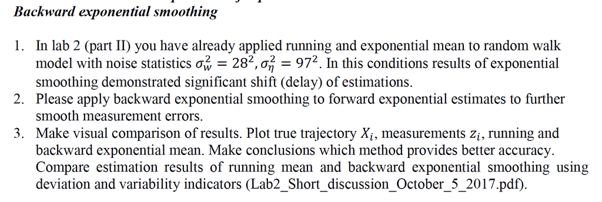

```python
%matplotlib inline
import pandas as pd
import numpy as np
from sklearn.metrics import mean_squared_error
from plotly import __version__
from plotly.offline import download_plotlyjs, init_notebook_mode, plot, iplot
import plotly.graph_objs as go
import matplotlib.pyplot as plt
from matplotlib.pyplot import figure


init_notebook_mode(connected=True)
```

```python
def generate_trajectory(x0 = 10, mean = 0, var = 0.1, steps = 100):
    trajectory = np.random.normal(loc = mean, scale = np.sqrt(var), size = steps)
    trajectory[0] = x0
    return np.cumsum(trajectory)
```

```python
def measure(trajectory, mean = 0, var = 0.1):
    noise = np.random.normal(loc = mean, scale = np.sqrt(var), size = trajectory.shape)
    return np.add(trajectory, noise)
```

```python
def exp_smooth(z, alpha):
    X = np.zeros(z.shape)
    X[0] = z[0]
    for i in range(1, z.shape[0]):
        X[i] = X[i-1] + alpha*(z[i] - X[i-1])
    return X
```

```python
trajectory = generate_trajectory(x0 = 10, var = 28**2, steps = 300)
```

```python
measurments = measure(trajectory, var = 97**2)
```

```python
alpha = 0.25
```

```python
exp_smoothed = exp_smooth(measurment, alpha)
```

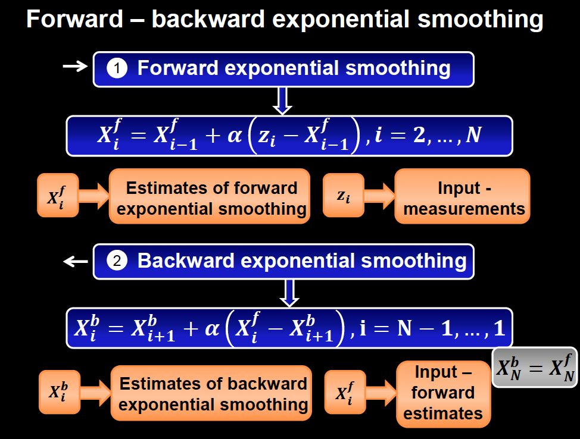

```python
def back_exp_smooth(exp_smoothed, alpha):
    B = np.zeros(exp_smoothed.shape[0])
    B[-1] = exp_smoothed[-1]
    for i in reversed(range(exp_smoothed.shape[0]-1)):
        B[i] = B[i+1] + alpha*(exp_smoothed[i] - B[i+1])
    return B
```

```python
back_exp_smoothed = back_exp_smooth(exp_smoothed, alpha)
```

```python
data = [
    go.Scatter(
        y=trajectory,
        name='trajectory'
    ),
    go.Scatter(
        y=measurments,
        name='measurments'
    ),
    go.Scatter(
        y=exp_smoothed,
        name='exp_smoothed'
    ),
    go.Scatter(
        y=back_exp_smoothed,
        name='back_exp_smoothed'
    ),
]

layout= go.Layout(
    title= 'True, measured, exp-smoothed and back-exp-smoothed',
    xaxis= dict(
        title= 'Steps',
    ),
    yaxis=dict(
        title= 'X',
    ),
    showlegend= True
)
fig= go.Figure(data=data, layout=layout)
iplot(fig)
```

[interactive chart not shown]

## By visual comparison it is clear, that backward exponential smoothing (BES) provides us with estimates that are closer to real trajectory. Curve gained with BES doesn't have delay, that we can see in forward exponential estimates. But it is less responsible to sudden changes. Still, it looks like BES provides better accuracy.

Compare estimation results of running mean and backward exponential smoothing using deviation and variability indicators

```python
M = 7
running_mean = pd.Series(measurments).rolling(window = M, center = True).mean()
```

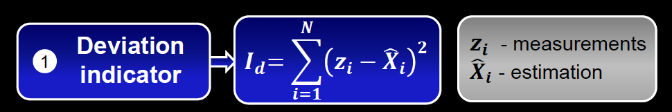

```python
def deviation_indicator(measurments, estimations):
    error = measurments - estimations
    return np.mean(error**2)
```

```python
running_mean_dev_ind = deviation_indicator(measurments, running_mean)
exp_smooth_dev_ind = deviation_indicator(measurments, exp_smoothed)
back_exp_smooth_dev_ind = deviation_indicator(measurments, back_exp_smoothed)
```

```python
running_mean_dev_ind, back_exp_smooth_dev_ind
```

```
(2371.367784665608, 1896.3446528470504)
```

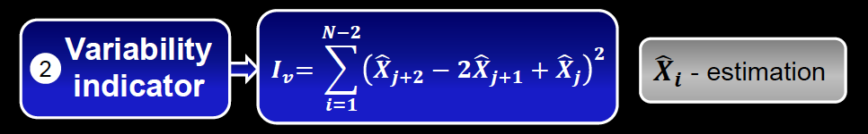

```python
#RM_variability = np.sum((np.add(np.subtract(running_mean[5:-3], 2*running_mean[4:-4]), running_mean[3:-5]))**2)
```

```python
def running_mean_variability(sequence, M):
    X_j2 = sequence[int(M/2)+2:-int(M/2)]
    X_j1 = sequence[int(M/2)+1:-(int(M/2)+1)]
    X_j = sequence[int(M/2):-(int(M/2)+2)]
    RM_variability = np.sum((np.add(np.subtract(X_j2, 2*X_j1), X_j))**2)
    return RM_variability
```

```python
RM_variability = running_mean_variability(running_mean, M)
```

```python
def exp_smooth_variability(sequence):
    return np.sum((sequence[2:] - 2*sequence[1:-1] + sequence[:-2])**2)
```

```python
BES_variability = exp_smooth_variability(back_exp_smoothed)
```

```python
RM_variability, BES_variability
```

```
(112.72842413029761, 15851.283484420555)
```

First we will analyze a process which rate of change is changed insignificantly and measurement noise is great.

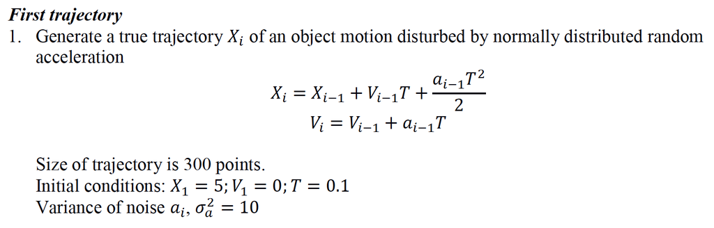

```python
# Accelerated motion
def generate_trajectory(X0 = 5, V0 = 0, T = 0.1, mean = 0, var = 0.1, steps = 300):
    velocity = np.zeros(steps)
    velocity[0] = V0
    accels = np.random.normal(loc = mean, scale = np.sqrt(var), size = steps)
    velocity[1:] = accels[:-1]*T
    velocity = np.cumsum(velocity)

    X = np.zeros(steps)
    X[0] = X0
    X[1:] = velocity[:-1]*T + accels[:-1]*(T**2)/2
    return np.cumsum(X)
```

```python
accel_motion = generate_trajectory(X0 = 5, V0 = 0, var = 10, steps = 300)
```

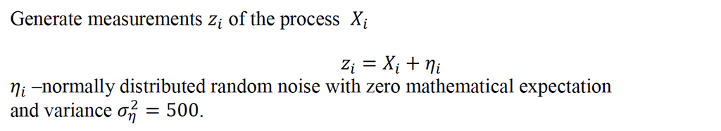

```python
def measure(trajectory, mean = 0, var = 0.1):
    noise = np.random.normal(loc = mean, scale = np.sqrt(var), size = trajectory.shape)
    return np.add(trajectory, noise)
```

```python
AccMot_measurments = measure(accel_motion, var = 500)
```

```python
data = [
    go.Scatter(
        y=accel_motion,
        name='Accellerated Motion'
    ),
    go.Scatter(
        y=AccMot_measurments,
        name='Accel Motion Measurments'
    ),
]

layout= go.Layout(
    title= 'Accellerated Motion and Accel Motion Measurments',
    xaxis= dict(
        title= 'Steps',
    ),
    yaxis=dict(
        title= 'X',
    ),
    showlegend= True
)
fig= go.Figure(data=data, layout=layout)
iplot(fig)
```

[interactive chart not shown]

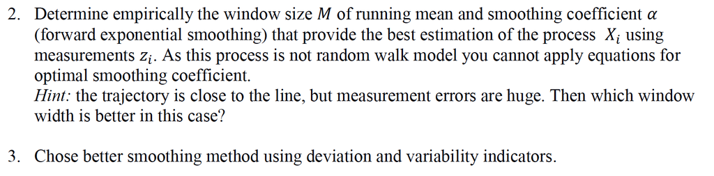

## Determine empirically the window size 𝑀 of running mean that provide the best estimation of the process 𝑋𝑖 using measurements 𝑧𝑖

```python
RM_dev_ind_dict = {}
RM_variability_dict = {}

for M in range(11, 100, 2):
    running_mean = pd.Series(AccMot_measurments).rolling(window = M, center = True).mean()
    RM_error = running_mean - accel_motion # running mean
    RM_var = np.var(RM_error, ddof = 1)
    running_mean_dev_ind = deviation_indicator(AccMot_measurments, running_mean)
    RM_dev_ind_dict.update({M:running_mean_dev_ind})
    RM_variability = running_mean_variability(running_mean, M)
    RM_variability_dict.update({M:RM_variability})
#     print("M is ", M)
#     print("I-deviation is", float("{:.2f}".format(running_mean_dev_ind)))
#     print("I-variability is", float("{:.2f}".format(RM_variability)))
#     print("variance is", float("{:.2f}".format(RM_var)))
#     print()


# RM_dev_ind_dict = pd.DataFrame(data=RM_dev_ind_dict, index=[0])
# RM_variability_dict = pd.DataFrame(data=RM_variability_dict, index=[0])
```

```python
#pd.Series(RM_dev_ind_dict).to_frame()
#pd.Series(RM_variability_dict).to_frame()
```

```python
data = [
    go.Scatter(
        y = list(RM_dev_ind_dict.values()),
        x = list(RM_dev_ind_dict.keys()),
        name = 'deviation'
    ),
    go.Scatter(
        y=list(RM_variability_dict.values()),
        x = list(RM_variability_dict.keys()),
        name='variability'
    ),
]

layout= go.Layout(
    title= 'Indicators for running mean',
    xaxis= dict(
        title= 'Steps',
    ),
    yaxis=dict(
        title= 'X',
    ),
    showlegend= True
)
fig= go.Figure(data=data, layout=layout)
iplot(fig)
```

[interactive chart not shown]

The window sise, that provides the best results is about 35, if my calculations are correct.

```python
running_mean = pd.Series(AccMot_measurments).rolling(window = 35, center = True).mean()
running_mean_dev_ind = deviation_indicator(AccMot_measurments, running_mean)
```

```python
data = [
    go.Scatter(
        y=accel_motion,
        name='Accellerated Motion'
    ),
#     go.Scatter(
#         y=AccMot_measurments,
#         name='Accel Motion Measurments'
#     ),
    go.Scatter(
        y=running_mean,
        name='running_mean ' # + str(M)
    )
]

layout= go.Layout(
    title= 'Running mean and Accellerated Motion',
    xaxis= dict(
        title= 'Steps',
    ),
    yaxis=dict(
        title= 'X',
    ),
    showlegend= True
)
fig= go.Figure(data=data, layout=layout)
iplot(fig)
```

[interactive chart not shown]

## Determine empirically smoothing coefficient 𝛼 (forward exponential smoothing) that provides the best estimation of the process 𝑋𝑖 using measurements 𝑧𝑖

```python
ES_dev_ind_dict = {}
ES_variability_dict = {}

#a = np.arange(0, 1, 0.05)
b = np.arange(0.01, 0.1, 0.01)
for alpha in b:
    exp_smoothed = exp_smooth(AccMot_measurments, alpha)
    ES_error = exp_smoothed - accel_motion # exp smoothing
    ES_var = np.var(ES_error, ddof = 1)
    exp_smooth_dev_ind = deviation_indicator(AccMot_measurments, exp_smoothed)
    ES_variability = exp_smooth_variability(exp_smoothed)

    ES_dev_ind_dict.update({alpha:exp_smooth_dev_ind})
    ES_variability_dict.update({alpha:ES_variability})

#     print("alpha is ", float("{:.2f}".format(alpha)))
#     print("I-deviation is", float("{:.2f}".format(exp_smooth_dev_ind)))
#     print("I-variablity is", float("{:.2f}".format(ES_variability)))
#     print("variance is", float("{:.2f}".format(ES_var)))
#     print()
```

```python
data = [
    go.Scatter(
        y = list(ES_dev_ind_dict.values()),
        x = list(ES_dev_ind_dict.keys()),
        name = 'ES_dev_ind_dict'
    ),
    go.Scatter(
        y=list(ES_variability_dict.values()),
        x = list(ES_variability_dict.keys()),
        name='ES_variability_dict'
    ),
]

layout= go.Layout(
    title= 'Indicators for Exp smoothing',
    xaxis= dict(
        title= 'Steps',
    ),
    yaxis=dict(
        title= 'X',
    ),
    showlegend= True
)
fig= go.Figure(data=data, layout=layout)
iplot(fig)
```

[interactive chart not shown]

```python
exp_smoothed = exp_smooth(AccMot_measurments, 0.04)
```

```python
data = [
    go.Scatter(
        y=accel_motion,
        name='Accellerated Motion'
    ),
#     go.Scatter(
#         y=AccMot_measurments,
#         name='Accel Motion Measurments'
#     ),
    go.Scatter(
        y=exp_smoothed,
        name='exp_smoothed'
    )
]

layout= go.Layout(
    title= 'Exponential smoothing and Accellerated Motion',
    xaxis= dict(
        title= 'Steps',
    ),
    yaxis=dict(
        title= 'X',
    ),
    showlegend= True
)
fig= go.Figure(data=data, layout=layout)
iplot(fig)
```

[interactive chart not shown]

Optimal coef alpha for exponential smoothing is 0.04.

Looks like running mean performs better with this magnitude of measurment noise.

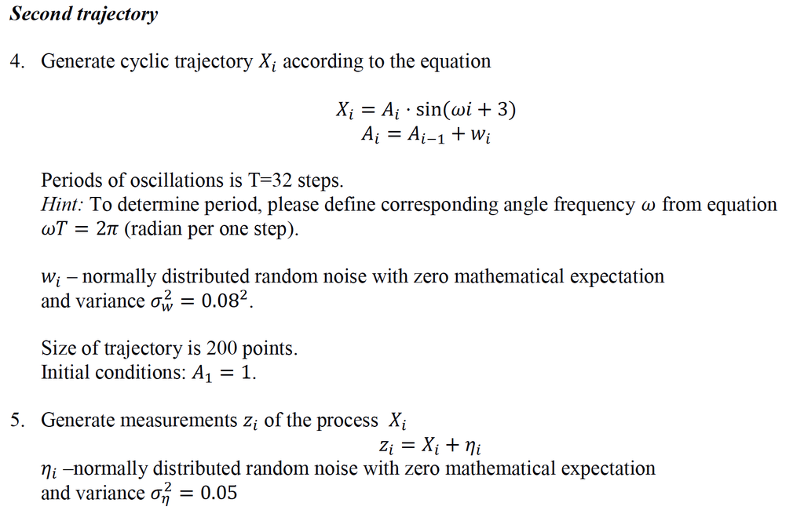

```python
def generate_trajectory(A0, mean = 0, T = 32, var = 0.1, steps = 200):
    i = np.arange(0, 200)
    w = np.random.normal(loc = mean, scale = np.sqrt(var), size = steps)
    w[0] = A0
    ampl = np.cumsum(w)
    X = np.multiply(ampl, np.sin((2*np.pi/T)*i + 3))
    return X
```

```python
cyclic_traj = generate_trajectory(A0 = 1, T = 32, var = 0.08**2, steps = 200)
CycTraj_measurments = measure(cyclic_traj, var = 0.05)
cycl_running_mean13 = pd.Series(CycTraj_measurments).rolling(window = 13, center = True).mean()
```

```python
data = [
    go.Scatter(
        y=cyclic_traj,
        name='cyclic_traj'
    ),
    go.Scatter(
        y=CycTraj_measurments,
        name='Measurments'
    ),
    go.Scatter(
        y=cycl_running_mean13,
        name='running_mean13'
    ),

]

layout= go.Layout(
    title= 'Cyclic trajectory',
    xaxis= dict(
        title= 'Steps',
    ),
    yaxis=dict(
        title= 'X',
    ),
    showlegend= True
)
fig= go.Figure(data=data, layout=layout)
iplot(fig)
```

[interactive chart not shown]

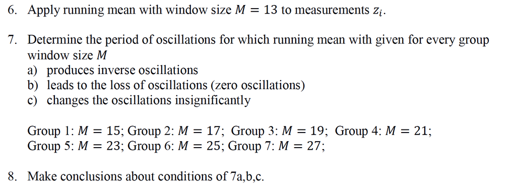

M = 17

gives us inverse oscillations: 5, 10, 11, 12, 13, 14, 15,

Decreases to zero: 17,

Not distorded in general: 20+

```python
cyclic_traj_10 = generate_trajectory(A0 = 1, T = 10, var = 0.08**2, steps = 200)
CycTraj_measurments_10 = measure(cyclic_traj_10, var = 0.05)
cycl_running_mean_10 = pd.Series(CycTraj_measurments_10).rolling(window = 17, center = True).mean()


data = [
    go.Scatter(
        y=cyclic_traj_10,
        name='cyclic traj with period 10'
    ),
    go.Scatter(
        y=cycl_running_mean_10,
        name='running mean with window 17'
    ),
]

layout= go.Layout(
    title= 'Inverse oscillations',
    xaxis= dict(
        title= 'Steps',
    ),
    yaxis=dict(
        title= 'X',
    ),
    showlegend= True
)
fig= go.Figure(data=data, layout=layout)
iplot(fig)
```

[interactive chart not shown]

```python
cyclic_traj_17 = generate_trajectory(A0 = 1, T = 17, var = 0.08**2, steps = 200)
CycTraj_measurments_17 = measure(cyclic_traj_17, var = 0.05)
cycl_running_mean_17 = pd.Series(CycTraj_measurments_17).rolling(window = 17, center = True).mean()


data = [
    go.Scatter(
        y=cyclic_traj_17,
        name='cyclic traj with period 17'
    ),
    go.Scatter(
        y=cycl_running_mean_17,
        name='running mean with window 17'
    ),
]

layout= go.Layout(
    title= 'Loss of oscillations',
    xaxis= dict(
        title= 'Steps',
    ),
    yaxis=dict(
        title= 'X',
    ),
    showlegend= True
)
fig= go.Figure(data=data, layout=layout)
iplot(fig)
```

[interactive chart not shown]

```python
cyclic_traj_30 = generate_trajectory(A0 = 1, T = 30, var = 0.08**2, steps = 200)
CycTraj_measurments_30 = measure(cyclic_traj_30, var = 0.05)
cycl_running_mean_30 = pd.Series(CycTraj_measurments_30).rolling(window = 17, center = True).mean()

data = [
    go.Scatter(
        y=cyclic_traj_30,
        name='cyclic traj with period 30'
    ),
    go.Scatter(
        y=cycl_running_mean_30,
        name='running mean with window 17'
    ),
]

layout= go.Layout(
    title= 'Insignificant changes in oscillations',
    xaxis= dict(
        title= 'Steps',
    ),
    yaxis=dict(
        title= 'X',
    ),
    showlegend= True
)
fig= go.Figure(data=data, layout=layout)
iplot(fig)
```

[interactive chart not shown]

## Make conclusions about conditions of 7a,b,c.

If choose size of the window bigger that oscillation period, than running mean curve tends to produce inverse oscillations. When size of the window and period of oscillation nearly equal than we can observe the loss of oscillations. And in case the size of a window is lesser than oscillation period, than we observe insignificant changes in oscillations.